# Visualizing Data from The nycflights13 Package

Mariia Karnaukh

2024-01-31

# Visualizing Flights of the New York Airport in 2013.

The following analysis makes use of the `nycflights13` package that contains several data-sets on airlines, airports, flights, planes and weather for the New York airport in the year 2013. I prepare below some visualization to better understand the trends presented in these data-sets.

## Step 0:

Loading the nycflights13 package and check what data-sets are bundled.

```r
library(nycflights13)
data(package = 'nycflights13')
```

## Step 1:

Visualizing the distribution of arrival delays per origin airport.

[figure not shown]

```r
library(ggplot2)
```

## Step 2:

Visualizing the distribution of arrival delays per destination airport.

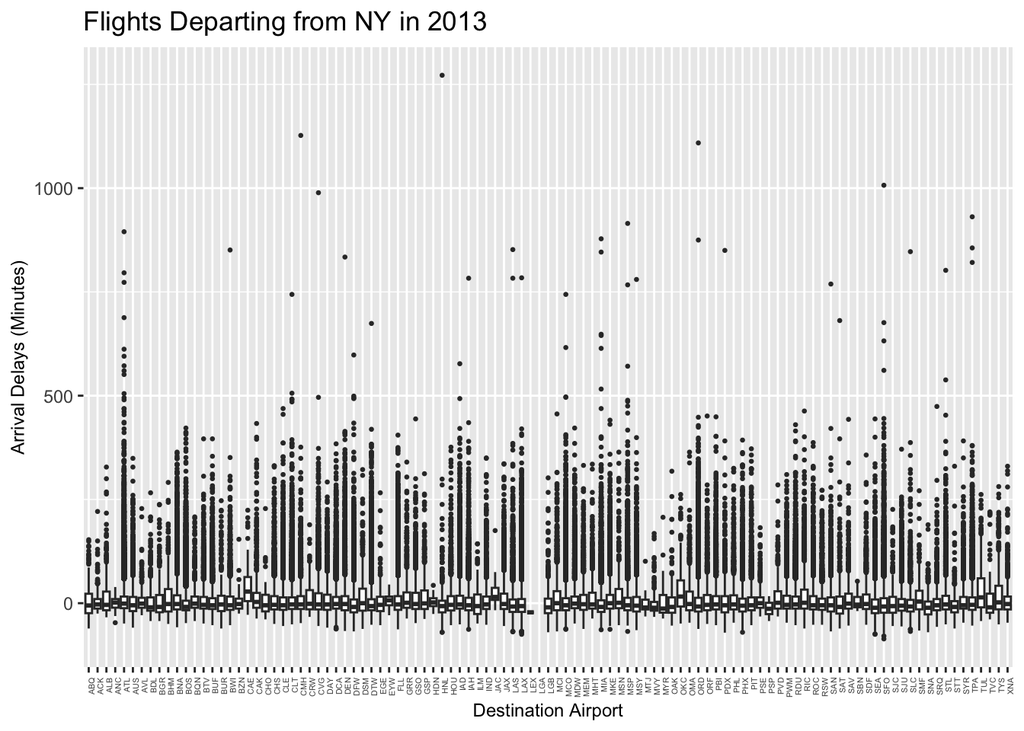

```r
ggplot(flights, aes(dest,arr_delay, label = dest)) +
  geom_boxplot(outlier.size = 0.5, lwd = 0.5) +
  theme_grey() +
  labs(title = 'Flights Departing from NY in 2013',
       x = 'Destination Airport',
       y = 'Arrival Delays (Minutes)') +
  theme(axis.text.x = element_text(angle = 90, hjust = 1, size = 4),
        axis.title.x = element_text(size = 9),
        axis.title.y = element_text(size = 9))
```

## Step 3:

Computing and visualizing the average arrival delay per destination.

```r
library(dplyr)
num_NA <- summary(is.na(flights))
num_NA ##arr_delay :9430 NA, about 3% of the data, drop NA
```

```
##     year           month            day           dep_time
##  Mode :logical   Mode :logical   Mode :logical   Mode :logical
##  FALSE:336776    FALSE:336776    FALSE:336776    FALSE:328521
##                                                  TRUE :8255
##  sched_dep_time  dep_delay        arr_time       sched_arr_time
##  Mode :logical   Mode :logical   Mode :logical   Mode :logical
##  FALSE:336776    FALSE:328521    FALSE:328063    FALSE:336776
##                  TRUE :8255      TRUE :8713
##  arr_delay        carrier          flight         tailnum
##  Mode :logical   Mode :logical   Mode :logical   Mode :logical
##  FALSE:327346    FALSE:336776    FALSE:336776    FALSE:334264
##  TRUE :9430                                      TRUE :2512
##    origin           dest          air_time        distance
##  Mode :logical   Mode :logical   Mode :logical   Mode :logical
##  FALSE:336776    FALSE:336776    FALSE:327346    FALSE:336776
##                                  TRUE :9430
##     hour           minute        time_hour
##  Mode :logical   Mode :logical   Mode :logical
##  FALSE:336776    FALSE:336776    FALSE:336776
##
```

```r
flights_c <- flights %>%
  filter(!(is.na(arr_delay)))

num_NA2 <- summary(is.na(flights_c))

avg_delay_table <- flights_c %>%
  group_by(dest) %>%
  summarise(avg_delay_dest = mean(arr_delay))
print(avg_delay_table)
```

```
## # A tibble: 104 × 2
##    dest  avg_delay_dest
##    <chr>          <dbl>
##  1 ABQ             4.38
##  2 ACK             4.85
##  3 ALB            14.4
##  4 ANC            -2.5
##  5 ATL            11.3
##  6 AUS             6.02
##  7 AVL             8.00
##  8 BDL             7.05
##  9 BGR             8.03
## 10 BHM            16.9
## # ℹ 94 more rows
```

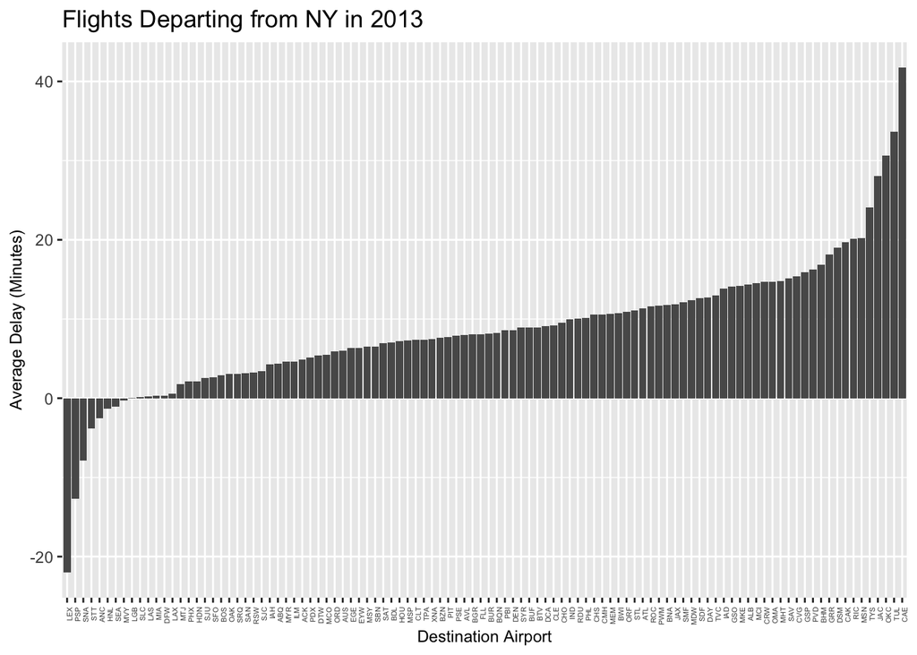

```r
num_NA3 <- summary(is.na(avg_delay_table))

ggplot(avg_delay_table, aes(reorder(dest, avg_delay_dest),avg_delay_dest, label = dest)) +
  geom_col() + labs(title = 'Flights Departing from NY in 2013',
                    x = 'Destination Airport',
                    y = 'Average Delay (Minutes)') +
  theme(axis.text.x = element_text(angle = 90, hjust = 1, size = 4),
        axis.title.x = element_text(size = 9),
        axis.title.y = element_text(size = 9))
```

## Step 4:

Redoing the above plot by showing the actual name of the destination airport instead of it’s FAA id.

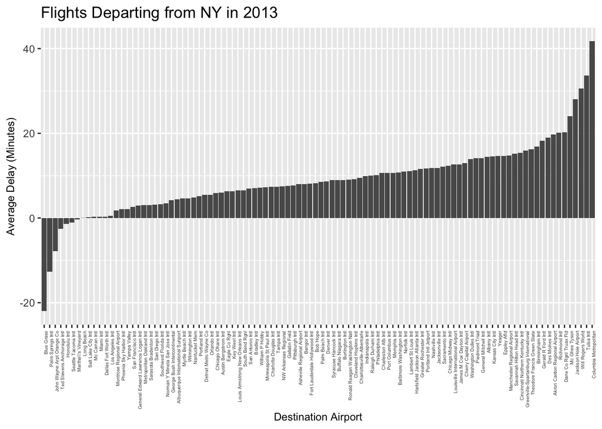

```r
data(airports)

avg_delay_table2 <- avg_delay_table %>%
  rename(faa = dest)

table2 <- avg_delay_table2 %>%
  left_join(airports, by = 'faa')

#Check for NA
num_NA4 <- summary(is.na(table2))

# Drop NA :100 unique values
table2 <- table2 %>%
  filter(!(is.na(lat)))

#Graph
ggplot(table2,
       aes(reorder(name, avg_delay_dest),avg_delay_dest, label = name)) +
  geom_col() + labs(title = 'Flights Departing from NY in 2013',
                    x = 'Destination Airport',
                    y = 'Average Delay (Minutes)') +
  theme(axis.text.x = element_text(angle = 90, hjust = 1, size = 4),
        axis.title.x = element_text(size = 9),
        axis.title.y = element_text(size = 9))
```

## Step 5:

Coloring the bars by the timezone of the airport.

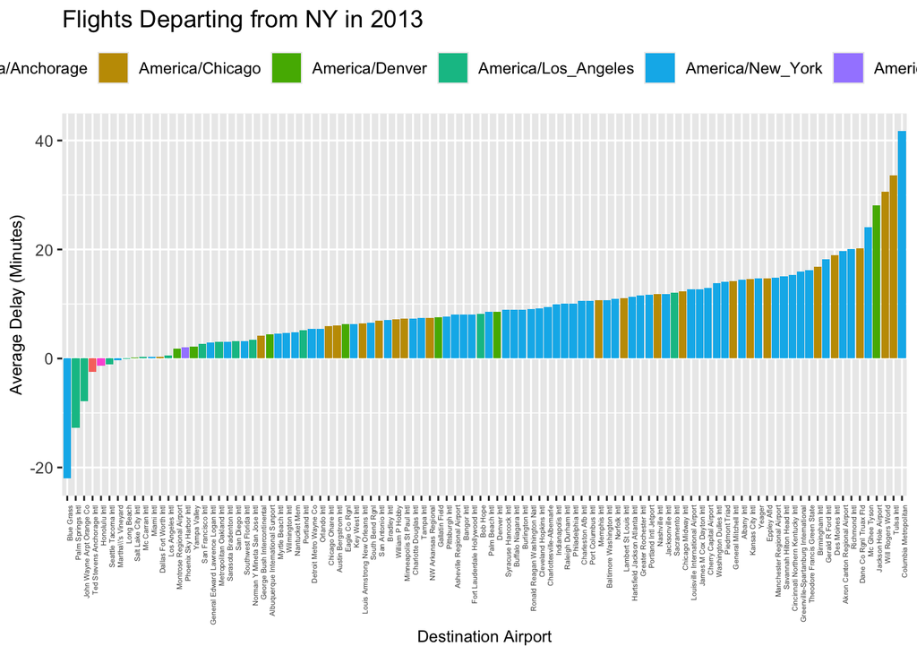

```r
ggplot(table2,
       aes(reorder(name, avg_delay_dest),avg_delay_dest,
           label = name, fill = tzone)) +
  geom_col() +
  labs(title = 'Flights Departing from NY in 2013',
                    x = 'Destination Airport',
                    y = 'Average Delay (Minutes)',
                    fill = 'Timezone') +
  theme(axis.text.x = element_text(angle = 90, hjust = 1, size = 4),
        axis.title.x = element_text(size = 9),
        axis.title.y = element_text(size = 9),
        legend.position = 'top',
        legend.direction = 'horizontal') +
  guides(fill = guide_legend(nrow = 1))
```

## Step 6:

Visualizing destination airports on a world-map with the point sizes relative to the number of flights to there from NY.

```r
# Add a new column with the number of time the airport was flown to
count_by_dest <- flights %>%
  count(dest, name = 'count_by_dest')
count_by_dest
```

```
## # A tibble: 105 × 2
##    dest  count_by_dest
##    <chr>         <int>
##  1 ABQ             254
##  2 ACK             265
##  3 ALB             439
##  4 ANC               8
##  5 ATL           17215
##  6 AUS            2439
##  7 AVL             275
##  8 BDL             443
##  9 BGR             375
## 10 BHM             297
## # ℹ 95 more rows
```

```r
airports_with_faa_count <- left_join(airports, count_by_dest, by = c('faa' = 'dest'))
airports_with_faa_count <- airports_with_faa_count %>%
  filter(!is.na(count_by_dest))
airports_with_faa_count
```

```
## # A tibble: 101 × 9
##    faa   name                   lat    lon   alt    tz dst   tzone count_by_dest
##    <chr> <chr>                <dbl>  <dbl> <dbl> <dbl> <chr> <chr>         <int>
##  1 ABQ   Albuquerque Interna…  35.0 -107.   5355    -7 A     Amer…           254
##  2 ACK   Nantucket Mem         41.3  -70.1    48    -5 A     Amer…           265
##  3 ALB   Albany Intl           42.7  -73.8   285    -5 A     Amer…           439
##  4 ANC   Ted Stevens Anchora…  61.2 -150.    152    -9 A     Amer…             8
##  5 ATL   Hartsfield Jackson …  33.6  -84.4  1026    -5 A     Amer…         17215
##  6 AUS   Austin Bergstrom In…  30.2  -97.7   542    -6 A     Amer…          2439
##  7 AVL   Asheville Regional …  35.4  -82.5  2165    -5 A     Amer…           275
##  8 BDL   Bradley Intl          41.9  -72.7   173    -5 A     Amer…           443
##  9 BGR   Bangor Intl           44.8  -68.8   192    -5 A     Amer…           375
## 10 BHM   Birmingham Intl       33.6  -86.8   644    -6 A     Amer…           297
## # ℹ 91 more rows
```

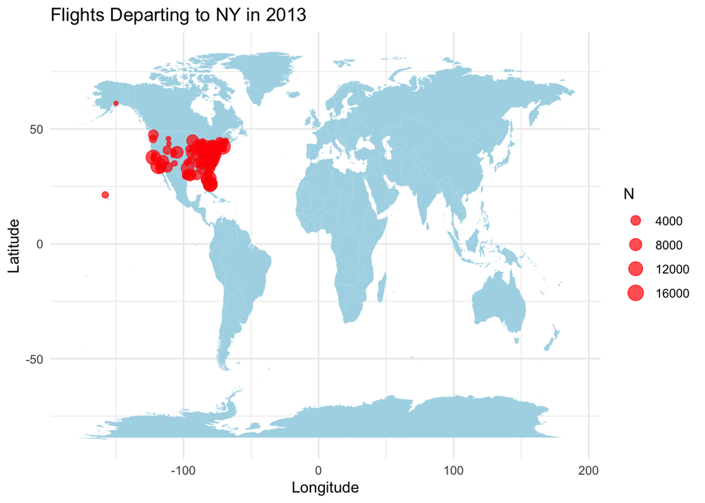

```r
# Create the map using ggplot2
world <- map_data('world')

ggplot() +
  geom_polygon(data = world, aes(x = long, y = lat, group = group),
               fill = 'lightblue') +
  geom_point(data = airports_with_faa_count,
             aes(x = lon, y = lat, size = count_by_dest), color = 'red', alpha = 0.7) +
  scale_size_continuous(range = c(1, 5)) +
  labs(title = 'Flights Departing to NY in 2013', x = 'Longitude',
       y = 'Latitude', size = 'N') +
  theme_minimal()
```

## Step 7:

Computing the average departure and arrival delays, also the average air time and distance per destination, then passing the scaled dataframe through MDS to visualize the similarities/dissimilarities of the destination airports.

```r
avg_vars <- flights %>%
  group_by(dest) %>%
  summarize(avg_dep_delay = mean(dep_delay, na.rm = TRUE),
            avg_arr_delay = mean(arr_delay, na.rm = TRUE),
            avg_air_time = mean(air_time, na.rm = TRUE),
            avg_distance = mean(distance, na.rm = TRUE))
head(avg_vars)
```

```
## # A tibble: 6 × 5
##   dest  avg_dep_delay avg_arr_delay avg_air_time avg_distance
##   <chr>         <dbl>         <dbl>        <dbl>        <dbl>
## 1 ABQ           13.7           4.38        249.         1826
## 2 ACK            6.46          4.85         42.1         199
## 3 ALB           23.6          14.4          31.8         143
## 4 ANC           12.9          -2.5         413.         3370
## 5 ATL           12.5          11.3         113.          757.
## 6 AUS           13.0           6.02        213.         1514.
```

```r
dest_codes <- avg_vars$dest

avg_vars2 <- scale(avg_vars[, -1])
head(avg_vars2)
```

```
##      avg_dep_delay avg_arr_delay avg_air_time avg_distance
## [1,]    -0.1782645    -0.5169200    0.8585015    0.8568093
## [2,]    -1.2636990    -0.4610332   -1.0640691   -1.0371177
## [3,]     1.2941612     0.6730029   -1.1595111   -1.1023051
## [4,]    -0.3071949    -1.3345658    2.3805427    2.6541192
## [5,]    -0.3616155     0.3050426   -0.4062372   -0.3874457
## [6,]    -0.2847456    -0.3223049    0.5202072    0.4939168
```

```r
mds <- cmdscale(dist(avg_vars2))
head(mds)
```

```
##            [,1]       [,2]
## [1,]  1.2834896 -0.3907013
## [2,] -0.3857177  1.8778179
## [3,] -2.0470252 -0.1764747
## [4,]  3.6148108 -1.4328434
## [5,] -0.4000246  0.3850654
## [6,]  0.8473403 -0.1166253
```

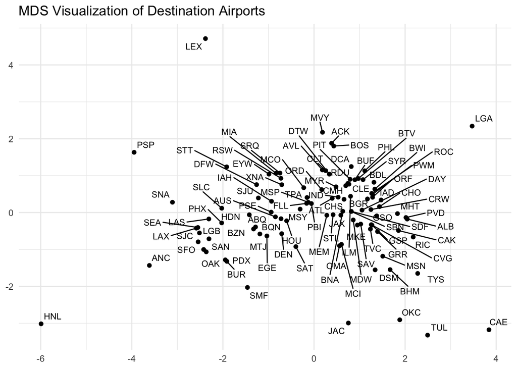

```r
#Plot using ggplot, convert to a data frame
mds <- as.data.frame(cmdscale(dist(scale(avg_vars2))))

#Flip horizontally
mds$V1 <- mds$V1 * -1
mds$dest <- dest_codes

# Plot MDS results using ggplot2
library(ggrepel)
ggplot(mds, aes(x = V1, y = V2, label = dest)) +
  geom_point() +
  geom_text_repel(aes(label = dest), size = 3, max.overlaps = 50) +
  labs(title = "MDS Visualization of Destination Airports",
       x = NULL,
       y = NULL) +
  theme_minimal()
```